# carreon_juluis_czar_week3

```python
%matplotlib inline
# import naming conventions
import numpy as np
import pandas as pd
import matplotlib.pyplot as plt

# (further reading on mpl imports: http://bit.ly/197aGoq )
```

## Part 1: data structures

There are two* main structures in `pandas`: Series (1-dimensional labeled array) and DataFrame (2-dimensional labeled structure).

* there is also a TimeSeries (a flavor of Series that contains datetimes), Panel (3-dimensional), and Panel4D (4-dimensional). The last two are 'less used,' according to the docs. I haven't experimented with them yet.

### Series (1D)

Series can hold any data type, and the axis label is called an index. Series is dict-like in that you can get and set values by index label.

```python
s1 = pd.Series([2,4,6,np.nan,8,9])
s1
```

```
0    2.0
1    4.0
2    6.0
3    NaN
4    8.0
5    9.0
dtype: float64
```

```python
# by default (without specifying them explicitly), the index label is just an int
s1[5]
```

```
9.0
```

### DataFrame (2D)

Columns can be of different data types. Index and column names are optional. If individual Series have different indexes, the DataFrame index will be the union of the individual ones.

Can create from:

- dict of 1D ndarrays, lists, dicts, or Series
- 2-D numpy.ndarray
- Series
- another DataFrame

N.B.: there are other helper methods for constructing DataFrames from varying data types; [see the docs](http://pandas.pydata.org/pandas-docs/stable/dsintro.html#alternate-constructors) for more options.

```python
# create a couple more Series
s2, s3 = pd.Series(np.random.randn(6)), pd.Series(np.random.randn(6))
```

```python
# combine multiple Series into a DataFrame with column labels
df_1 = pd.DataFrame({'A': s1, 'B': s2, 'C': s3})

df_1
```

|  | A | B | C |
| --- | --- | --- | --- |
| 0 | 2.0 | -1.105216 | -1.049751 |
| 1 | 4.0 | -1.235755 | -0.870871 |
| 2 | 6.0 | -1.268151 | 0.350513 |
| 3 | NaN | -0.554751 | 0.618210 |
| 4 | 8.0 | 0.332718 | 0.959324 |
| 5 | 9.0 | 0.017923 | -0.169112 |

```python
# when Series are different lengths, DataFrame fills in gaps with NaN
s4 = pd.Series(np.random.randn(8))  # whoaaaaaa this Series has extra entries!

df1 = pd.DataFrame({'A': s1, 'B': s2, 'C': s3, 'D': s4})

df1
```

|  | A | B | C | D |
| --- | --- | --- | --- | --- |
| 0 | 2.0 | -1.105216 | -1.049751 | 0.210818 |
| 1 | 4.0 | -1.235755 | -0.870871 | 0.429870 |
| 2 | 6.0 | -1.268151 | 0.350513 | -1.554244 |
| 3 | NaN | -0.554751 | 0.618210 | -1.260596 |
| 4 | 8.0 | 0.332718 | 0.959324 | -1.482217 |
| 5 | 9.0 | 0.017923 | -0.169112 | -0.373179 |
| 6 | NaN | NaN | NaN | -1.013195 |
| 7 | NaN | NaN | NaN | 0.789058 |

```python
# create a DataFrame from numpy array
df2 = pd.DataFrame(np.random.randn(6,4))

df2             # can only have one 'pretty' output per cell (if it's the last command)

#print df2       # otherwise, can print arb number of results w/o pretty format
#print df1       # (uncomment both of these print statements)
```

|  | 0 | 1 | 2 | 3 |
| --- | --- | --- | --- | --- |
| 0 | -0.289501 | 0.908718 | -0.661821 | 1.300793 |
| 1 | 0.413526 | -0.174920 | -0.292342 | -0.079246 |
| 2 | -0.199610 | -0.245880 | 0.869517 | 0.887614 |
| 3 | -0.898490 | -1.736029 | -0.436598 | 0.682354 |
| 4 | -2.000167 | 0.757308 | -1.380137 | 1.094304 |
| 5 | -0.851321 | 1.226173 | 1.027310 | -0.680280 |

Can inspect your DataFrames with head() and tail() methods - takes a number of lines as an argument.

Without specifiying them, DataFrames have default index and column name attributes.

```python
# recall current dataframe
df2.head(3)
```

|  | 0 | 1 | 2 | 3 |
| --- | --- | --- | --- | --- |
| 0 | -0.289501 | 0.908718 | -0.661821 | 1.300793 |
| 1 | 0.413526 | -0.174920 | -0.292342 | -0.079246 |
| 2 | -0.199610 | -0.245880 | 0.869517 | 0.887614 |

But you can assign to those attributes of the DataFrame...

```python
cols = ['a', 'b', 'c', 'd']

# assign columns attribute (names)
df2.columns = cols

# create an index:
# generate a sequence of dates with pandas' data_range() method,
# then assign the index attribute
dates = pd.date_range(start='2013-11-24 13:45:27', freq='W', periods=6)
df2.index = dates

df2
```

|  | a | b | c | d |
| --- | --- | --- | --- | --- |
| 2013-11-24 13:45:27 | -0.289501 | 0.908718 | -0.661821 | 1.300793 |
| 2013-12-01 13:45:27 | 0.413526 | -0.174920 | -0.292342 | -0.079246 |
| 2013-12-08 13:45:27 | -0.199610 | -0.245880 | 0.869517 | 0.887614 |
| 2013-12-15 13:45:27 | -0.898490 | -1.736029 | -0.436598 | 0.682354 |
| 2013-12-22 13:45:27 | -2.000167 | 0.757308 | -1.380137 | 1.094304 |
| 2013-12-29 13:45:27 | -0.851321 | 1.226173 | 1.027310 | -0.680280 |

```python
# an aside: inspecting the dates object...
print 'what is a date_range object?\n\n', dates
```

```
what is a date_range object?

DatetimeIndex(['2013-11-24 13:45:27', '2013-12-01 13:45:27',
               '2013-12-08 13:45:27', '2013-12-15 13:45:27',
               '2013-12-22 13:45:27', '2013-12-29 13:45:27'],
              dtype='datetime64[ns]', freq='W-SUN')
```

Do some indexing / subsetting...

```python
# select a row by index label by using .loc
df2.loc['2013-12-01 13:45:27']
```

```
a    0.413526
b   -0.174920
c   -0.292342
d   -0.079246
Name: 2013-12-01 13:45:27, dtype: float64
```

```python
# select a single element
df2.loc['2013-12-22 13:45:27','a']
```

```
-2.000166795064418
```

```python
# new dataframe with random numbers
df1 = pd.DataFrame(np.random.randn(6,4), index=list('abcdef'),columns=list('ABCD'))

df1
```

|  | A | B | C | D |
| --- | --- | --- | --- | --- |
| a | 1.167313 | 0.155328 | -1.385523 | 0.855846 |
| b | -0.320699 | 0.941730 | 0.741484 | -0.804851 |
| c | 0.716899 | 0.955588 | 0.817749 | 0.191365 |
| d | 0.753351 | 2.089980 | 0.410921 | -1.933294 |
| e | 0.914905 | 1.185949 | -0.090817 | 1.589271 |
| f | 0.097340 | -1.420084 | -0.158385 | 0.988350 |

```python
# address two separate rows, and a range of three columns
df1.loc[['d','e'],'A':'C']
```

|  | A | B | C |
| --- | --- | --- | --- |
| d | 0.753351 | 2.089980 | 0.410921 |
| e | 0.914905 | 1.185949 | -0.090817 |

## part 2: data

In the `data/` directory is the sample of parsed twitter data that floats around with gnacs. To create the string of column names, I just used the explain option with all other options.

```python
gnacs_x = "id|postedTime|body|None|['twitter_entiteis:urls:url']|['None']|['actor:languages_list-items']|gnip:language:value|twitter_lang|[u'geo:coordinates_list-items']|geo:type|None|None|None|None|actor:utcOffset|None|None|None|None|None|None|None|None|None|actor:displayName|actor:preferredUsername|actor:id|gnip:klout_score|actor:followersCount|actor:friendsCount|actor:listedCount|actor:statusesCount|Tweet|None|None|None"
colnames = gnacs_x.split('|')
```

```python
# prevent the automatic compression of wide dataframes (add scroll bar)
pd.set_option("display.max_columns", None)

# get some data, inspect
df1 = pd.read_csv('../Data/twitter_sample.csv', sep='|', names=colnames)

df1.tail(7)
```

[output not shown]

Since there are so many explain fields that come back with 'None', let's just get rid of them for now.

(In the future, we might try to find a way to make that field more descriptive, too.)

```python
# n.b.: this is an *in-place* delete -- unusual for a pandas structure
del df1['None']

# The command below is how the docs suggest carrying this out (creating a new df).
#   But, it doesn't seem to work -- possibly due to multiple cols with same name. Oh well.
#new_df = df1.drop('None', axis=1)  # return new df
```

```python
# have a peek
df1.tail(6)
```

[output not shown]

## slicing & combining

Subsetting a DataFrame is very similar to the syntax in R. There are two ways to select columns: 'dot' (attribute) notation, and 'square bracket' (index) notation. Sometimes, the column names will dictate which you have to use.

```python
# inspect those rows with twitter-classified lang 'en' (scroll the right to see)
df1[df1.twitter_lang == 'en'].head()

# the colons in the column name below won't allow dot-access to the column, so we can quote them and still filter.
#df1[df1["gnip:language:value"] == 'en'].head()
```

|  | id | postedTime | body | ['twitter_entiteis:urls:url'] | ['None'] | ['actor:languages_list-items'] | gnip:language:value | twitter_lang | [u'geo:coordinates_list-items'] | geo:type | None.1 | None.2 | None.3 | None.4 | actor:utcOffset | None.5 | None.6 | None.7 | None.8 | None.9 | None.10 | None.11 | None.12 | None.13 | actor:displayName | actor:preferredUsername | actor:id | gnip:klout_score | actor:followersCount | … |
| --- | --- | --- | --- | --- | --- | --- | --- | --- | --- | --- | --- | --- | --- | --- | --- | --- | --- | --- | --- | --- | --- | --- | --- | --- | --- | --- | --- | --- | --- | --- |
| 475 | <td id="LC9" class="blob-code blob-cod... | 2013-07-01T22:50:51.000Z | @pafcdan Aww good! X | None | None | [&#39;en&#39;] | en | en | [50.3582949, -4.0930973] | Point | [&#39;[-4.209496, 50.3320883]&#39;, &#39;[-4.2... | Polygon | Plymouth, Plymouth | GB | 0 | Plymouth | None | None | None | None | None | None | None | None | Becky ❤ | BeckyLou90x | 26568635.0 | 38 | 380.0 | … |
| 479 | <td id="LC10" class="blob-code blob-co... | 2013-07-01T22:50:51.000Z | Newest hobby: sending videos back and forth of... | None | None | [&#39;en&#39;] | en | en | [29.54588264, -95.10669141] | Point | [&#39;[-95.145152, 29.506973]&#39;, &#39;[-95.... | Polygon | Webster, TX | US | None | Houston, Texas | None | None | None | None | None | None | None | None | lil beyoncé | beezlebrat | 541953037.0 | 41 | 160.0 | … |
| 487 | <td id="LC12" class="blob-code blob-co... | 2013-07-01T22:50:51.000Z | ~FINALLY OFF OF WORK~ | None | None | [&#39;en&#39;] | en | en | [32.86107, -83.72062] | Point | [&#39;[-83.739741, 32.765651]&#39;, &#39;[-83.... | Polygon | Macon, GA | US | None | None | None | None | None | None | None | None | None | None | Tomeisha Cross | MISSMEISHA223 | 242505369.0 | 18 | 290.0 | … |
| 491 | <td id="LC13" class="blob-code blob-co... | 2013-07-01T22:50:51.000Z | Rubbing/massaging my feet is like giving me he... | None | None | [&#39;en&#39;] | en | en | [33.68890281, -84.27369741] | Point | [&#39;[-85.605165, 30.355756999999997]&#39;, &... | Polygon | Georgia, US | US | -18000 | Atl... | None | None | None | None | None | None | None | None | Poison † | shanbonita | 29619102.0 | 64 | 40543.0 | … |
| 503 | <td id="LC16" class="blob-code blob-co... | 2013-07-01T22:50:51.000Z | @Hayley_Brownn Same!!!! Very sad times😞😞😞😞 | None | None | [&#39;en&#39;] | en | en | [54.6884467, -3.51776393] | Point | [&#39;[-3.580063, 54.454108]&#39;, &#39;[-3.58... | Polygon | Allerdale, Cumbria | GB | -36000 | None | None | None | None | None | None | None | None | None | Karl Hine | KarlHine | 402334657.0 | 42 | 417.0 | … |

Let's get a subset of this dataframe that has numerical values so we can eventually do some stuff.

```python
# create new dataframe from numerical columns
df2 = df1[["gnip:klout_score","actor:followersCount", "actor:friendsCount", "actor:listedCount"]]

df2.head()
```

|  | gnip:klout_score | actor:followersCount | actor:friendsCount | actor:listedCount |
| --- | --- | --- | --- | --- |
| 0 | NaN | NaN | NaN | NaN |
| 1 | NaN | NaN | NaN | NaN |
| 2 | NaN | NaN | NaN | NaN |
| 3 | NaN | NaN | NaN | NaN |
| 4 | NaN | NaN | NaN | NaN |

```python
# because I happen to know the answer, let's check data types of the columns...
df2.dtypes
```

```
gnip:klout_score         object
actor:followersCount    float64
actor:friendsCount      float64
actor:listedCount       float64
dtype: object
```

The `object` type means that the column has multiple types of data in it. This is a good opportunity to 'fix' a section of the DataFrame by way of a function & the `map()` function

```python
# convert ints / strings to floats, give up on anything else (call it 0.0)
def floatify(val):
    if val == None or val == 'None':
        return 0.0
    else:
        return float(val)
```

```python
# assigning to an existing column overwrites that column
df2['gnip:klout_score'] = df2['gnip:klout_score'].map(floatify)

# check again
df2.dtypes
```

```
gnip:klout_score        float64
actor:followersCount    float64
actor:friendsCount      float64
actor:listedCount       float64
dtype: object
```

```python
# use all floats just for fun.
#  this only works if the elements can all be converted to floats (e.g. ints or something python can handle)
df2 = df2.astype(float)

df2.dtypes
```

```
gnip:klout_score        float64
actor:followersCount    float64
actor:friendsCount      float64
actor:listedCount       float64
dtype: object
```

Since they're all numbers now, we can do math and also add new columns to the DataFrame. Combining values from separate columns occurs on a row-by-row basis, as expected.

```python
# look at some activity ratios - add col to df
df2['fol/fr'] = df2['gnip:klout_score'] / df2['actor:followersCount']

df2.head()

# can also use the built-in describe() method to get quick descriptive stats on the dataframe
#df2.describe()
```

|  | gnip:klout_score | actor:followersCount | actor:friendsCount | actor:listedCount | fol/fr |
| --- | --- | --- | --- | --- | --- |
| 0 | NaN | NaN | NaN | NaN | NaN |
| 1 | NaN | NaN | NaN | NaN | NaN |
| 2 | NaN | NaN | NaN | NaN | NaN |
| 3 | NaN | NaN | NaN | NaN | NaN |
| 4 | NaN | NaN | NaN | NaN | NaN |

## grouping

groupby() is used for the split-apply-combine process. I'm led to believe that this is one of the stronger aspects of `pandas`' approach to DataFrames (versus R's), but haven't yet had a chance to really see the power.

```python
# back to bigger df, without 'None' cols
df1.head()
```

[output not shown]

Use a groupby to collect all rows by language value, and subsequently use some of the methods available to `GroupBy` DataFrames. Note that the `GroupBy` methods will only act on (and the method call only return) values for columns where numerical calculation makes sense.

```python
# subset df, create new df with only 'popular' accounts -- those matching the filter condition given
pop_df = df1[df1["actor:followersCount"] >= 100]

# fix the klout scores again
#pop_df['gnip:klout_score'] = pop_df['gnip:klout_score'].map(floatify)

# in case you need to remind yourself of the dataframe
#pop_df.head()

# use GroupBy methods for stats on each group:
#pop_df.groupby("twitter_lang").size()      # number of elements per group
#pop_df.groupby("twitter_lang").sum()       # sum of elements in each group (obviously doesn't make sense for some cols)
#pop_df.groupby("twitter_lang").mean()      # algebraic mean of elements per group
```

```python
# though this looks like a normal dataframe, the DataFrameGroupBy object has a heirarchical index
#  this means it may not act as you might expect.
lang_gb = pop_df[['twitter_lang',\
             'gnip:klout_score',\
             'actor:followersCount',\
             'actor:friendsCount',\
             'actor:statusesCount']].groupby('twitter_lang')


# note the new index 'twitter_lang' -- in this case, .head(n) returns <= n elements for each index
lang_gb.head(2)

# see that they type is DataFrameGroupBy object
#lang_gb
```

|  | twitter_lang | gnip:klout_score | actor:followersCount | actor:friendsCount | actor:statusesCount |
| --- | --- | --- | --- | --- | --- |
| 443 | tr | 35 | 178.0 | 129.0 | 2028.0 |
| 447 | es | 32 | 144.0 | 215.0 | 4071.0 |
| 455 | es | 50 | 438.0 | 174.0 | 17636.0 |
| 463 | tr | 41 | 226.0 | 346.0 | 7759.0 |
| 467 | pt | 42 | 247.0 | 64.0 | 2438.0 |
| 475 | en | 38 | 380.0 | 860.0 | 3116.0 |
| 479 | en | 41 | 160.0 | 135.0 | 4170.0 |
| 507 | und | 53 | 1179.0 | 628.0 | 20141.0 |
| 515 | he | 37 | 151.0 | 284.0 | 641.0 |
| 523 | it | 46 | 1999.0 | 293.0 | 60236.0 |
| 527 | pt | 43 | 137.0 | 89.0 | 4047.0 |
| 531 | id | 43 | 258.0 | 302.0 | 2732.0 |
| 539 | pl | 48 | 2037.0 | 1984.0 | 23240.0 |
| 559 | id | 33 | 404.0 | 378.0 | 9181.0 |
| 575 | ko | 39 | 170.0 | 120.0 | 1094.0 |
| 595 | und | 35 | 228.0 | 185.0 | 24571.0 |
| 611 | ar | 40 | 458.0 | 413.0 | 1061.0 |
| 615 | fr | 40 | 116.0 | 122.0 | 3174.0 |
| 699 | ja | 28 | 152.0 | 335.0 | 2151.0 |
| 763 | fr | 43 | 305.0 | 241.0 | 12230.0 |
| 779 | lv | 41 | 297.0 | 237.0 | 5221.0 |
| 815 | vi | 44 | 767.0 | 486.0 | 17549.0 |
| 823 | it | 53 | 5084.0 | 3802.0 | 30163.0 |

```python
# to get a DataFrame object that responds more like I'm used to, create a new one using the
#   aggregate method, which results in a single-index DataFrame
lang_gb_mean = lang_gb.aggregate(np.mean)

lang_gb_mean.head()

# verify the single index
#lang_gb_mean.index
```

| twitter_lang | actor:followersCount | actor:friendsCount | actor:statusesCount |
| --- | --- | --- | --- |
| ar | 458.000000 | 413.000000 | 1061.000000 |
| en | 1774.371429 | 577.257143 | 17264.314286 |
| es | 1287.533333 | 426.133333 | 8650.733333 |
| fr | 210.500000 | 181.500000 | 7702.000000 |
| he | 151.000000 | 284.000000 | 641.000000 |

## part 3: plotting

As far as I can tell, plotting in Python was not fun in the past. Below is some easy, base matplotlib, but 'nice' graphics take *a lot* of code. This situation is changing quite quickly now, with the success of `ggplot2` in the R world and the attempts to a) make `matplotlib` look less sucky, and b) implement the Grammar of Graphics in Python.

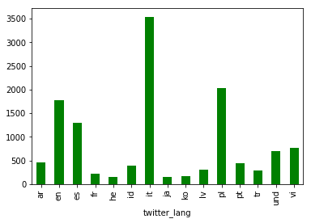

```python
# .plot() is a pandas wrapper for matplotlib's plt.plot()
lang_gb_mean['actor:followersCount'].plot(kind='bar', color='g')
```

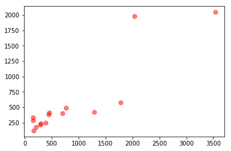

```python
# more base matplotlib
plt.scatter(x=lang_gb_mean['actor:followersCount'],\
            y=lang_gb_mean['actor:friendsCount'],\
            alpha=0.5,\
            s=50,\
            color='red',\
            marker='o')
```

[output not shown]

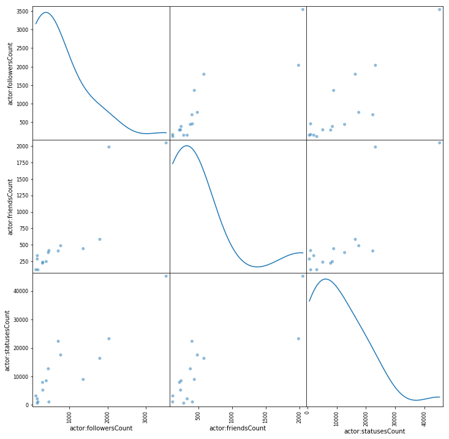

```python
# now read the docs and copypasta a neat-looking plot
from pandas.plotting import scatter_matrix

scatter_matrix(lang_gb_mean, alpha=0.5, figsize=(12,12), diagonal='kde', s=100)
```

Finally, a short taste of some other plotting libraries. My munging + plotting skillz in this world are still a work in progress, so I will definitely return to this section with an actual use-case in the future. For now, we'll make up some data for illustrative purposes.

```python
# make up some data with large-scale patterns and a datetime index
df = pd.DataFrame(np.random.randn(1000, 4), index=pd.date_range('1/1/2000', periods=1000), columns=list('ABCD'))
df = df.cumsum()
df.head()
```

|  | A | B | C | D |
| --- | --- | --- | --- | --- |
| 2000-01-01 | 0.695418 | 0.733028 | 0.150012 | -1.851863 |
| 2000-01-02 | 0.718804 | -0.475930 | 0.517355 | -1.120140 |
| 2000-01-03 | -0.239574 | -1.089259 | 0.492250 | -1.548065 |
| 2000-01-04 | 1.013982 | -0.641555 | 0.200909 | -3.652253 |
| 2000-01-05 | -0.043525 | 0.193098 | 1.346408 | -3.477297 |

[output not shown]

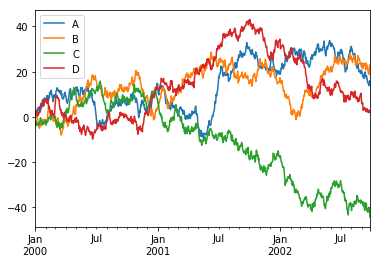

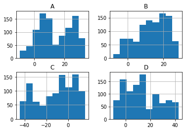

```python
df.plot()
df.hist()
```

Now, let's use some other matplotlib wrappers to get a sense of how we can make this look a little better....

[output not shown]

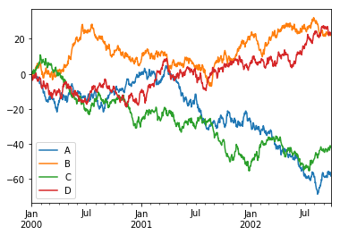

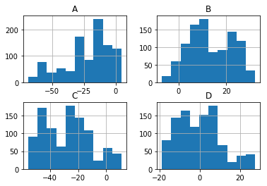

```python
import prettyplotlib

df.plot()
df.hist()
```

# Visualizing the distribution of a dataset

When dealing with a set of data, often the first thing you'll want to do is get a sense for how the variables are distributed. This chapter of the tutorial will give a brief introduction to some of the tools in seaborn for examining univariate and bivariate distributions. You may also want to look at the :ref:`categorical plots <categorical_tutorial>` chapter for examples of functions that make it easy to compare the distribution of a variable across levels of other variables.

```python
%matplotlib inline
```

```python
import numpy as np
import pandas as pd
from scipy import stats, integrate
import matplotlib.pyplot as plt
```

```python
import seaborn as sns
sns.set(color_codes=True)
```

```python
np.random.seed(sum(map(ord, "distributions")))
```

## Plotting univariate distributions

The most convenient way to take a quick look at a univariate distribution in seaborn is the ***`distplot` function. By default, this will draw a `histogram <https://en.wikipedia.org/wiki/Histogram>`_ and fit a `kernel density estimate <https://en.wikipedia.org/wiki/Kernel_density_estimation>`_ (KDE).

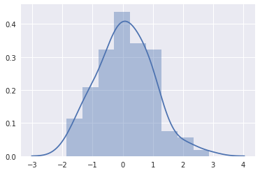

```python
x = np.random.normal(size=100)
sns.distplot(x);
```

**Histograms**

Histograms are likely familiar, and a **`hist`** function already exists in matplotlib. A histogram represents the distribution of data by forming bins along the range of the data and then drawing bars to show the number of observations that fall in each bin.

To illustrate this, let's remove the density curve and add a rug plot, which draws a small vertical tick at each observation. You can make the rug plot itself with the **`rugplot`** function, but it is also available in **`distplot`**:

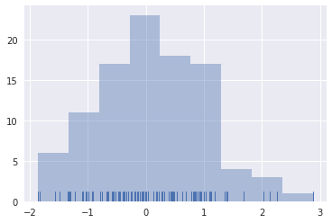

```python
sns.distplot(x, kde=False, rug=True);
```

When drawing histograms, the main choice you have is the number of bins to use and where to place them. **`distplot`** uses a simple rule to make a good guess for what the right number is by default, but trying more or fewer bins might reveal other features in the data:

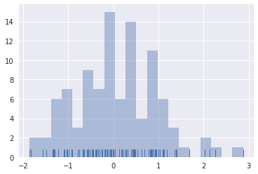

```python
sns.distplot(x, bins=20, kde=False, rug=True);
```

**Kernel density estimaton**

The kernel density estimate may be less familiar, but it can be a useful tool for plotting the shape of a distribution. Like the histogram, the KDE plots encodes the density of observations on one axis with height along the other axis:

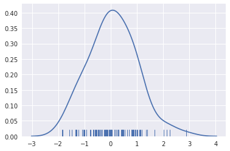

```python
sns.distplot(x, hist=False, rug=True);
```

Drawing a KDE is more computationally involved than drawing a histogram. What happens is that each observation is first replaced with a normal (Gaussian) curve centered at that value:

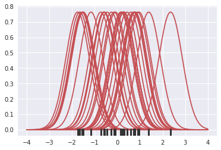

```python
x = np.random.normal(0, 1, size=30)
bandwidth = 1.06 * x.std() * x.size ** (-1 / 5.)
support = np.linspace(-4, 4, 200)

kernels = []
for x_i in x:

    kernel = stats.norm(x_i, bandwidth).pdf(support)
    kernels.append(kernel)
    plt.plot(support, kernel, color="r")

sns.rugplot(x, color=".2", linewidth=3);
```

Next, these curves are summed to compute the value of the density at each point in the support grid. The resulting curve is then normalized so that the area under it is equal to 1:

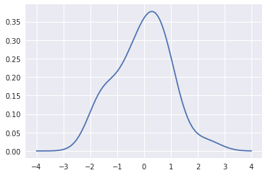

```python
density = np.sum(kernels, axis=0)
density /= integrate.trapz(density, support)
plt.plot(support, density);
```

We can see that if we use the **`kdeplot`** function in seaborn, we get the same curve. This function is used by **`distplot`**, but it provides a more direct interface with easier access to other options when you just want the density estimate:

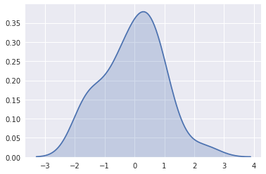

```python
sns.kdeplot(x, shade=True);
```

The bandwidth (`bw`) parameter of the KDE controls how tightly the estimation is fit to the data, much like the bin size in a histogram. It corresponds to the width of the kernels we plotted above. The default behavior tries to guess a good value using a common reference rule, but it may be helpful to try larger or smaller values:

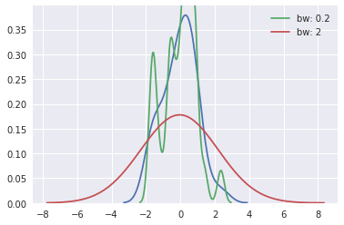

```python
sns.kdeplot(x)
sns.kdeplot(x, bw=.2, label="bw: 0.2")
sns.kdeplot(x, bw=2, label="bw: 2")
plt.legend();
```

As you can see above, the nature of the Gaussian KDE process means that estimation extends past the largest and smallest values in the dataset. It's possible to control how far past the extreme values the curve is drawn with the `cut` parameter; however, this only influences how the curve is drawn and not how it is fit:

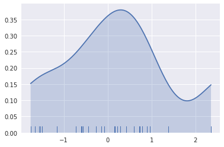

```python
sns.kdeplot(x, shade=True, cut=0)
sns.rugplot(x);
```

**Fitting parametric distributions**

You can also use **`distplot`** to fit a parametric distribution to a dataset and visually evaluate how closely it corresponds to the observed data:

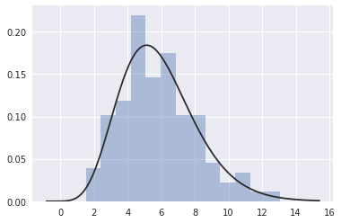

```python
x = np.random.gamma(6, size=200)
sns.distplot(x, kde=False, fit=stats.gamma);
```

## Plotting bivariate distributions

It can also be useful to visualize a bivariate distribution of two variables. The easiest way to do this in seaborn is to just use the ***`jointplot` function, which creates a multi-panel figure that shows both the bivariate (or joint) relationship between two variables along with the univariate (or marginal) distribution of each on separate axes.

```python
mean, cov = [0, 1], [(1, .5), (.5, 1)]
data = np.random.multivariate_normal(mean, cov, 200)
df = pd.DataFrame(data, columns=["x", "y"])
```

**Scatterplots**

The most familiar way to visualize a bivariate distribution is a scatterplot, where each observation is shown with point at the *x* and *y* values. This is analgous to a rug plot on two dimensions. You can draw a scatterplot with the matplotlib **`plt.scatter`** function, and it is also the default kind of plot shown by the **`jointplot`** function:

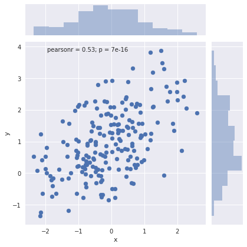

```python
sns.jointplot(x="x", y="y", data=df);
```

**Hexbin plots**

The bivariate analogue of a histogram is known as a **"hexbin"** plot, because it shows the counts of observations that fall within hexagonal bins. This plot works best with relatively large datasets. It's available through the matplotlib **`plt.hexbin`** function and as a style in **`jointplot`**. It looks best with a white background:

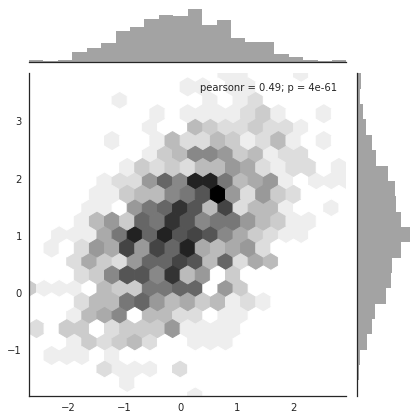

```python
x, y = np.random.multivariate_normal(mean, cov, 1000).T
with sns.axes_style("white"):
    sns.jointplot(x=x, y=y, kind="hex", color="k");
```

**Kernel density estimation**

It is also posible to use the kernel density estimation procedure described above to visualize a bivariate distribution. In seaborn, this kind of plot is shown with a contour plot and is available as a style in **`jointplot`**:

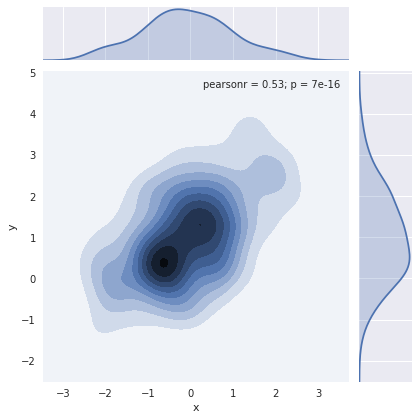

```python
sns.jointplot(x="x", y="y", data=df, kind="kde");
```

You can also draw a two-dimensional kernel density plot with the **`kdeplot`** function. This allows you to draw this kind of plot onto a specific (and possibly already existing) matplotlib axes, whereas the **`jointplot`** function manages its own figure:

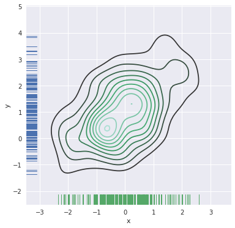

```python
f, ax = plt.subplots(figsize=(6, 6))
sns.kdeplot(df.x, df.y, ax=ax)
sns.rugplot(df.x, color="g", ax=ax)
sns.rugplot(df.y, vertical=True, ax=ax);
```

If you wish to show the bivariate density more continuously, you can simply increase the number of contour levels:

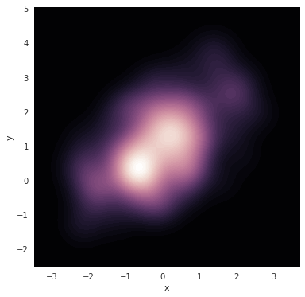

```python
f, ax = plt.subplots(figsize=(6, 6))
cmap = sns.cubehelix_palette(as_cmap=True, dark=0, light=1, reverse=True)
sns.kdeplot(df.x, df.y, cmap=cmap, n_levels=60, shade=True);
```

The **`jointplot`** function uses a **`JointGrid`** to manage the figure. For more flexibility, you may want to draw your figure by using **`JointGrid`** directly. **`jointplot` returns the** `JointGrid`** object after plotting, which you can use to add more layers or to tweak other aspects of the visualization:

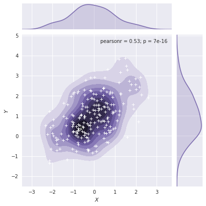

```python
g = sns.jointplot(x="x", y="y", data=df, kind="kde", color="m")
g.plot_joint(plt.scatter, c="w", s=30, linewidth=1, marker="+")
g.ax_joint.collections[0].set_alpha(0)
g.set_axis_labels("$X$", "$Y$");
```

## Visualizing pairwise relationships in a dataset

To plot multiple pairwise bivariate distributions in a dataset, you can use the **`pairplot`** function. This creates a matrix of axes and shows the relationship for each pair of columns in a DataFrame. By default, it also draws the univariate distribution of each variable on the diagonal Axes:

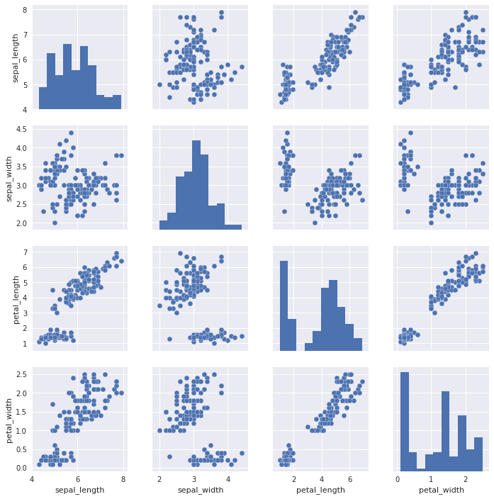

```python
iris = sns.load_dataset("iris")
sns.pairplot(iris);
```

Much like the relationship between **`jointplot`** and **`JointGrid`**, the **`pairplot`** function is built on top of a **`PairGrid`** object, which can be used directly for more flexibility:

```
No handlers could be found for logger "matplotlib.legend"
```

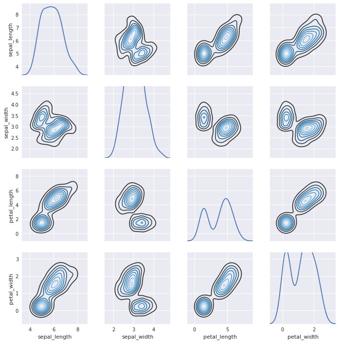

```python
g = sns.PairGrid(iris)
g.map_diag(sns.kdeplot)
g.map_offdiag(sns.kdeplot, cmap="Blues_d", n_levels=8);
```

# Visualizing linear relationships

```python
%matplotlib inline
```

```python
import numpy as np
import pandas as pd
import matplotlib as mpl
import matplotlib.pyplot as plt
```

```python
import seaborn as sns
sns.set(color_codes=True)
```

```python
np.random.seed(sum(map(ord, "regression")))
```

```python
tips = sns.load_dataset("tips")
```

## Functions to draw linear regression models

Two main functions in seaborn are used to visualize a linear relationship as determined through regression. These functions, **`regplot`** and **`lmplot`** are closely related, and share much of their core functionality. It is important to understand the ways they differ, however, so that you can quickly choose the correct tool for particular job.

In the simplest invocation, both functions draw a scatterplot of two variables, `x` and `y`, and then fit the regression model `y ~ x` and plot the resulting regression line and a 95% confidence interval for that regression:

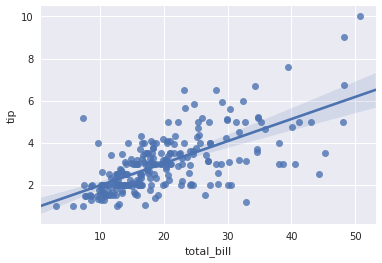

```python
sns.regplot(x="total_bill", y="tip", data=tips);
```

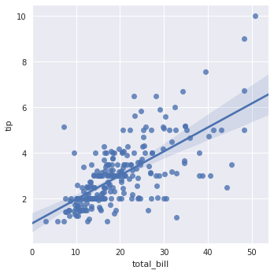

```python
sns.lmplot(x="total_bill", y="tip", data=tips);
```

You should note that the resulting plots are identical, except that the figure shapes are different. We will explain why this is shortly. For now, the other main difference to know about is that **`regplot`** accepts the `x` and `y` variables in a variety of formats including simple numpy arrays, pandas `Series` objects, or as references to variables in a pandas `DataFrame` object passed to `data`. In contrast, **`lmplot`** has `data` as a required parameter and the `x` and `y` variables must be specified as strings. This data format is called "long-form" or `"tidy" <http://vita.had.co.nz/papers/tidy-data.pdf>`_ data. Other than this input flexibility, **`regplot`** possesses a subset of **`lmplot`**'s features, so we will demonstrate them using the latter.

It's possible to fit a linear regression when one of the variables takes discrete values, however, the simple scatterplot produced by this kind of dataset is often not optimal:

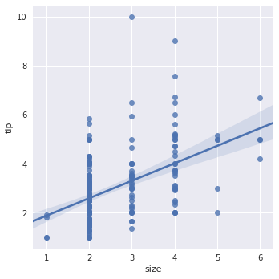

```python
sns.lmplot(x="size", y="tip", data=tips);
```

One option is to add some random noise ("jitter") to the discrete values to make the distribution of those values more clear. Note that jitter is applied only to the scatterplot data and does not influence the regression line fit itself:

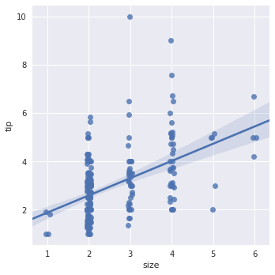

```python
sns.lmplot(x="size", y="tip", data=tips, x_jitter=.05);
```

A second option is to collapse over the observations in each discrete bin to plot an estimate of central tendency along with a confidence interval:

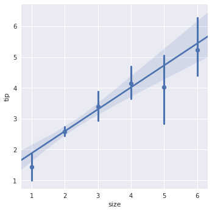

```python
sns.lmplot(x="size", y="tip", data=tips, x_estimator=np.mean);
```